# Movies Analysis - Clusters

Francisco Castillo, Fernanda Esquivel y Andrés Montoya

29/01/2024

```r
#install.packages("factoextra")
# install.packages("fpc")
# install.packages("clustertend")
# install.packages("hopkins")
```

```r
library(factoextra)
library(fpc)
library(hopkins)
library(cluster)
```

# Movies Analysis

## 1. Preprocesamiento de datos

```r
movies <- read.csv("data/movies.csv")
useful <- c("popularity", "budget", "revenue", "genresAmount",
                      "runtime", "productionCountriesAmount", "voteCount",
                      "voteAvg", "actorsAmount", "castWomenAmount", "castMenAmount")
# Parse Cast Women Amount and Cast Men Amount to numeric
movies$castWomenAmount <- as.numeric(movies$castWomenAmount)
movies$castMenAmount <- as.numeric(movies$castMenAmount)
movies_new <- subset(movies, select = useful)
movies_new <- na.omit(movies_new)
# Scale the data
for_analysis <- movies_new
movies_new <- scale(movies_new)
summary(movies_new)
```

```
##    popularity           budget            revenue          genresAmount
##  Min.   :-0.21671   Min.   :-0.51150   Min.   :-0.38260   Min.   :-1.4186
##  1st Qu.:-0.16958   1st Qu.:-0.51150   1st Qu.:-0.38260   1st Qu.:-0.5366
##  Median :-0.13620   Median :-0.48692   Median :-0.38042   Median : 0.3453
##  Mean   : 0.00000   Mean   : 0.00000   Mean   : 0.00000   Mean   : 0.0000
##  3rd Qu.:-0.05014   3rd Qu.: 0.05886   3rd Qu.:-0.07587   3rd Qu.: 0.3453
##  Max.   :52.29687   Max.   : 9.80940   Max.   :18.52196   Max.   : 4.7552
##     runtime         productionCountriesAmount   voteCount
##  Min.   :-3.76589   Min.   :-0.57967          Min.   :-0.528404
##  1st Qu.:-0.40813   1st Qu.:-0.24825          1st Qu.:-0.479172
##  Median :-0.03504   Median :-0.24825          Median :-0.362099
##  Mean   : 0.00000   Mean   : 0.00000          Mean   : 0.000000
##  3rd Qu.: 0.44997   3rd Qu.: 0.08318          3rd Qu.:-0.007102
##  Max.   :24.21547   Max.   :50.79067          Max.   :11.406416
##     voteAvg          actorsAmount     castWomenAmount   castMenAmount
##  Min.   :-5.41717   Min.   :-1.2193   Min.   :-1.1379   Min.   :-0.1648
##  1st Qu.:-0.61718   1st Qu.:-0.6466   1st Qu.:-0.6604   1st Qu.:-0.1648
##  Median : 0.00891   Median :-0.2942   Median :-0.1828   Median :-0.1647
##  Mean   : 0.00000   Mean   : 0.0000   Mean   : 0.0000   Mean   : 0.0000
##  3rd Qu.: 0.73934   3rd Qu.: 0.3666   3rd Qu.: 0.2948   3rd Qu.:-0.1646
##  Max.   : 3.66108   Max.   :12.5691   Max.   :15.7363   Max.   : 9.0135
```

### Variables no utiles

- Id: Es el identificador unico y no proporciona información relevante
- original_title y title: Representan el nombre de la película, por lo que no aportan información relevante a menos que se realice un análisis especifico de los nombres de las películas
- originalLanguage: Representa el idioma original de la película, no aporta información relevante
- homePage y video: No aporta información relevante para la agrupación de las películas
- productionCoAmount, productionCompany y productionCompanyCountry: A pesar de que es importante para el análisis especifico de las películas, no aporta información relevante para la agrupación
- actors y actorsCharacter: A pesar de que es importante para el análisis especifico de las películas, no aporta información relevante para la agrupación
- actorsPopularity: Ya que da información sobre la popularidad de cada uno de los actores, no aporta información relevante para la agrupación
- releaseDate: No es cuantitativa, por lo que no aporta información relevante para la agrupación
- director: No es una variable cuantitativa, por lo que no puede ser utilizada para la agrupación
- genres: No es cuantitativa, por lo que no aporta información relevante para la agrupación
- productionCountry: No es cuantitativa, por lo que no aporta información relevante para la agrupación

## 2. Virtual Assessment of cluster Tendency (VAT)

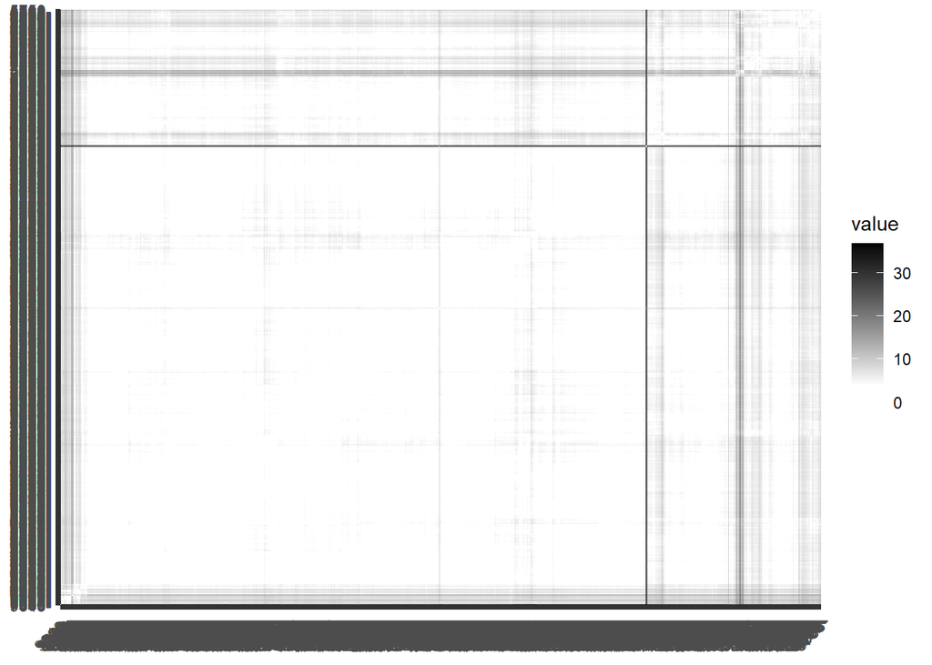

```r
# Seed for the random sample
set.seed(1313)
# Sample of 1500 rows
sample <- movies_new[sample(1:nrow(movies_new), 1500),]
# Distribution of the sample
distribution <- get_dist(sample)

# Visualize the distribution as a heatmap
fviz_dist(distribution, gradient = list(low= "#ffffff", mid = "white", high ="#000000"))
```

Al realizar el análisis de la distribución de las variables por medio de un heatmap, se puede observar que no se forman clusters claros, por lo que se procederá a realizar un análisis de clusters para determinar la cantidad de clusters que se pueden formar.

## 3. Elbow Method

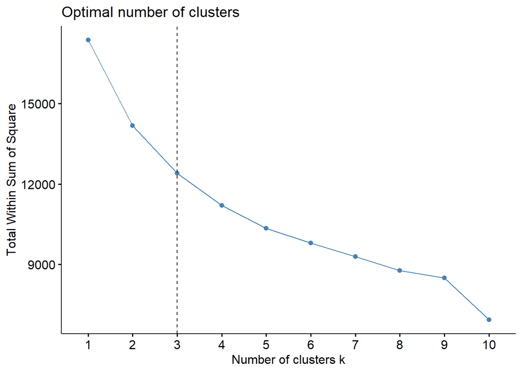

```r
set.seed(1313)
sample <- movies_new[sample(1:nrow(movies_new), 1500),]
fviz_nbclust(sample, kmeans, method = "wss") + geom_vline(xintercept = 3, linetype = 2)
```

Al realizar el análisis del método del codo, se puede observar que el codo se encuentra entre 3 y 4 clusters. Debido a la poca diferencia entre 3 y 4 clusters, se procederá a realizar un análisis de clusters con 3 clusters priorizando así la simplicidad del modelo y el tiempo de ejecución.

## 4. Clustering

### 4.1. K-means

```r
# Seed for the random sample
set.seed(1313)
kmeans_model_4 <- kmeans(movies_new, centers = 4, nstart = 25)
```

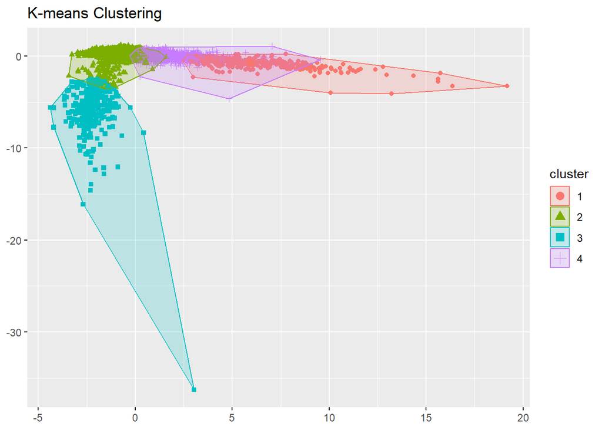

```r
fviz_cluster(
        kmeans_model_4,
        data = movies_new,
        geom = "point",
        ellipse.type = "convex",
        ellipse = TRUE,
        stand = TRUE,
        xlab = FALSE,
        ylab = FALSE,
        main = "K-means Clustering"
)
```

```r
# Seed for the random sample
set.seed(1313)
kmeans_model_3 <- kmeans(movies_new, centers = 3, nstart = 25)
```

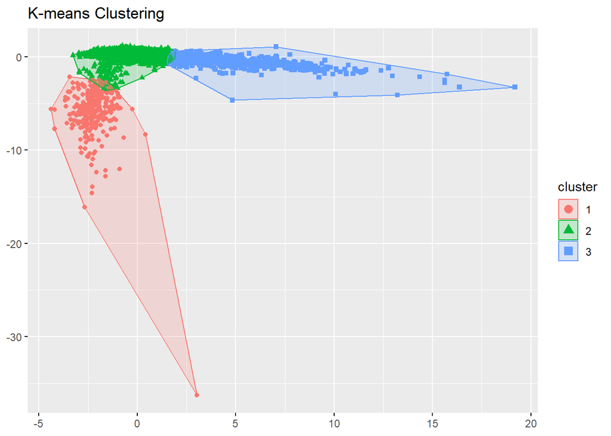

```r
fviz_cluster(
        kmeans_model_3,
        data = movies_new,
        geom = "point",
        ellipse.type = "convex",
        ellipse = TRUE,
        stand = TRUE,
        xlab = FALSE,
        ylab = FALSE,
        main = "K-means Clustering"
)
```

### 4.2. Hierarchical Clustering

```r
# Hierarchical clustering with 4 clusters
hirarchical_model <- hclust(dist(movies_new), method = "complete")
```

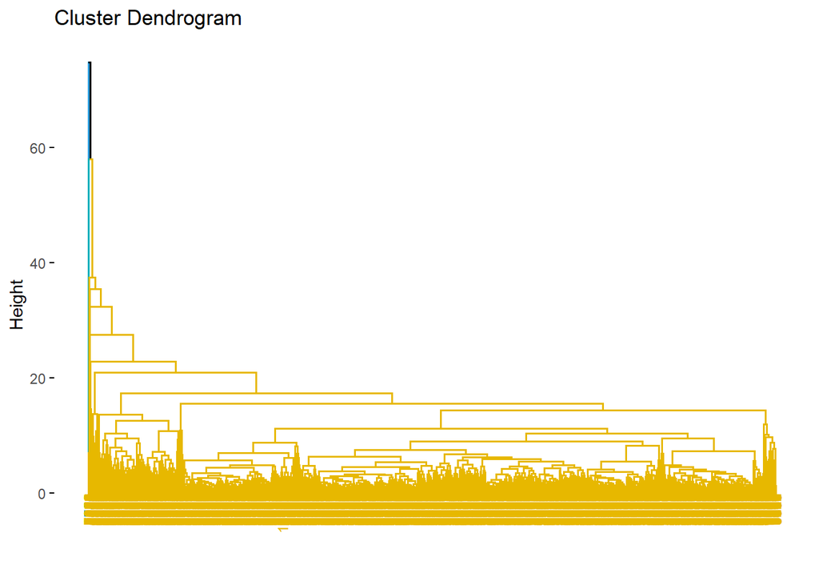

```r
# Visualize the dendrogram
fviz_dend(hirarchical_model, k = 3, cex = 0.6, k_colors = c("#2E9FDF", "#00AFBB", "#E7B800", "#FC4E07"))
```

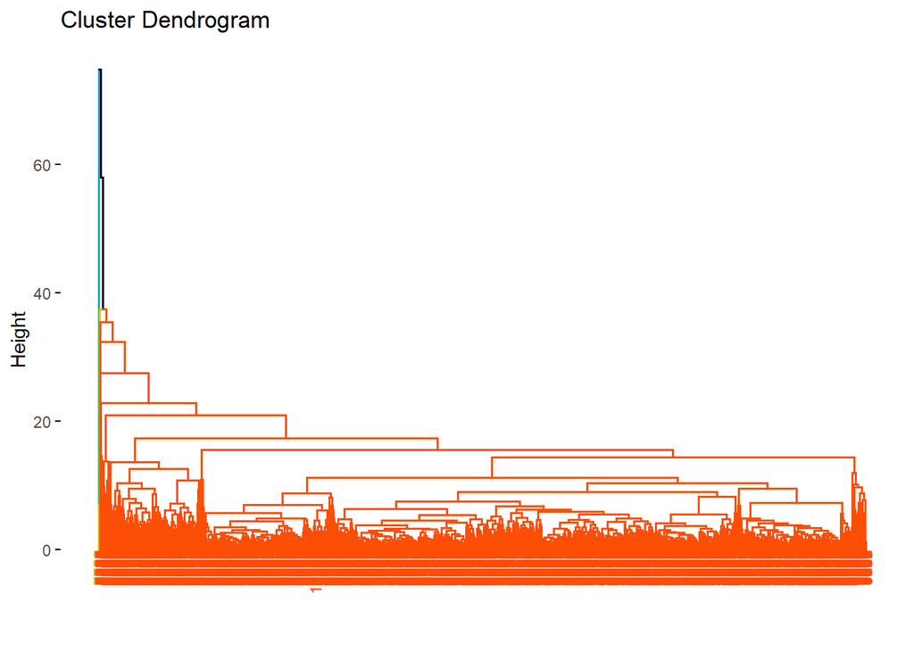

```r
fviz_dend(hirarchical_model, k = 4, cex = 0.6, k_colors = c("#2E9FDF", "#00AFBB", "#E7B800", "#FC4E07"))
```

## 5. Silhouette Analysis

```r
silhouette_kmeans_4 <- silhouette(kmeans_model_4$cluster, dist(movies_new))
```

```r
silhouette_kmeans_3 <- silhouette(kmeans_model_3$cluster, dist(movies_new))
```

```r
silhouette_hierarchical_4 <- silhouette(cutree(hirarchical_model, k = 4), dist(movies_new))
```

```r
silhouette_hierarchical_3 <- silhouette(cutree(hirarchical_model, k = 3), dist(movies_new))
```

```
##   cluster size ave.sil.width
## 1       1  424          0.08
## 2       2 6580          0.33
## 3       3  286          0.21
## 4       4 2548          0.06
```

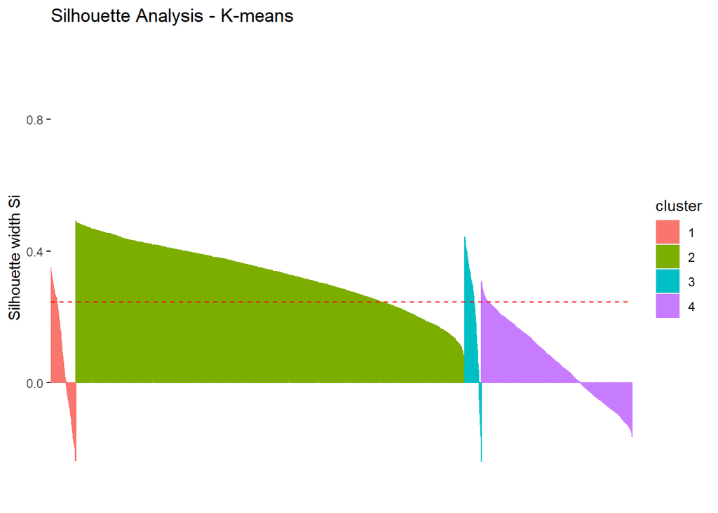

```r
fviz_silhouette(silhouette_kmeans_4) + labs(title = "Silhouette Analysis - K-means")
```

```
##   cluster size ave.sil.width
## 1       1  287          0.22
## 2       2 8312          0.53
## 3       3 1239          0.01
```

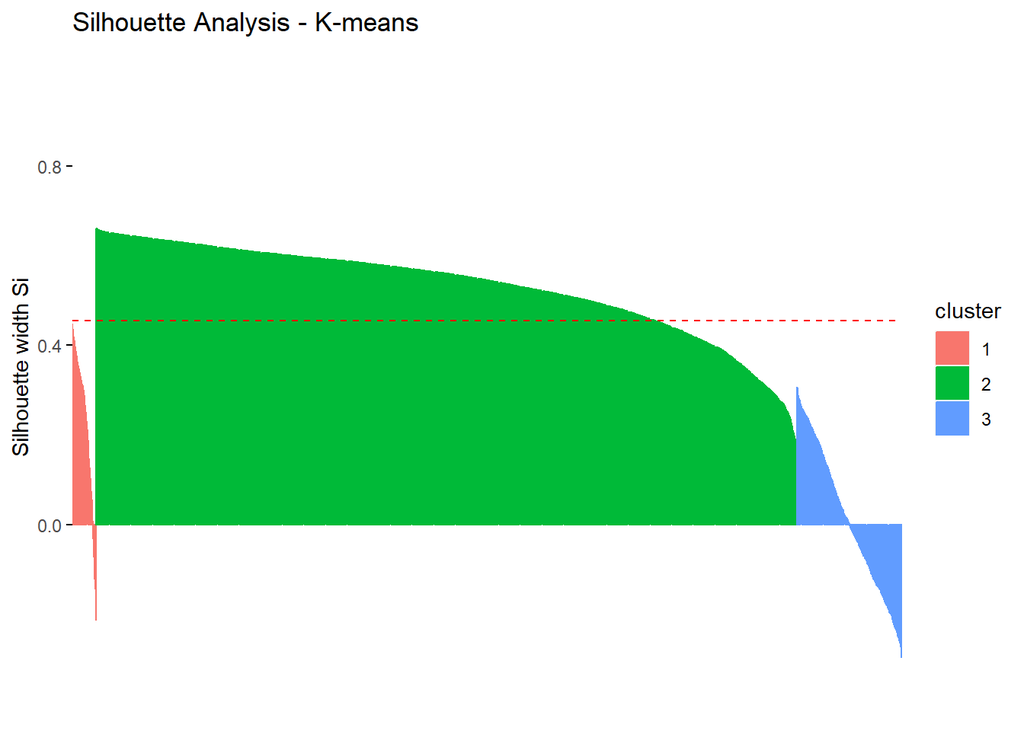

```r
fviz_silhouette(silhouette_kmeans_3) + labs(title = "Silhouette Analysis - K-means")
```